# Nationally Determined Contributions (NDC) Text Analysis

. This exercise aims to analyze the data from the reports on Nationally Determined Contributions (NDC) of seven Caribbean countries. The reports are in pdf files, which are read by the tessaeract package and processed for analysis. The text is tokenized and analyzed for n-grams, word frequency, and other relevant information.

Loading the required libraries.

```r
# Libraries
library(dplyr)
library(magick)
library(pdftools)
library(reactable)
library(stringr)
library(tesseract)
library(tidyr)
library(tidytext)
library(widyr)
library(wordcloud2)
```

Create a dictionary to map country abbreviations to full country names.

```r
dict_country <- data.frame(
    country_abbr = c("antigua", "barbados", "dominica", "grenada", "lucia", "vincent", "kitts"),
    country_name = c("Antigua and Barbuda", "Barbados", "Dominica", "Grenada", "Saint Lucia", "Saint Vincent and the Grenadines", "St. Kitts and Nevis"))
```

Read the pdf files for all countries and create a dataframe with the text.

You don’t need to run this code block. The data is already saved as an RDS file and can be loaded in the next code block.

```r
# Function to read text from PDF using Tesseract
read_pdf_tesseract <- function(pdf_path) {
  # Load the PDF
  pdf_info <- pdf_info(pdf_path)
  num_pages <- pdf_info$pages

  all_text <- ""

  for (page in 1:num_pages) {
    # Convert PDF page to image
    pdf_image <- pdf_render_page(pdf_path, page = page, dpi = 300)
    img <- image_read(pdf_image)

    # Perform OCR on the image
    text <- ocr(img)
    all_text <- paste(all_text, text, sep = "\n")
  }

  return(all_text)
}

# Specify the path to your PDF file
pdf_file_antigua <- "docs/ATG - UNFCCC NDC - 2021-09-02 - Final.pdf"
pdf_file_barbados <- "docs/2021 Barbados NDC update - 21 July 2021.pdf"
pdf_file_dominica <- "docs/The Commonwealth of Dominica updated NDC July 4 ,.pdf"
pdf_file_grenada <- "docs/GrenadaSecondNDC2020 - 01-12-20.pdf"
pdf_file_saint_lucia <- "docs/Saint Lucia First NDC (Updated submission).pdf"
pdf_file_saint_vincent <- "docs/Saint Vincent and the Grenadines_NDC.pdf"
pdf_file_st_kitts <- "docs/St. Kitts and Nevis Revised NDC_Updated.pdf"

pdf_files <- c(pdf_file_antigua, pdf_file_barbados, pdf_file_dominica, pdf_file_grenada, pdf_file_saint_lucia, pdf_file_saint_vincent, pdf_file_st_kitts)

# Read text from the PDF
pdf_texts <- list()

for (pdf_file in pdf_files) {
  pdf_text <- read_pdf_tesseract(pdf_file)

  pdf_texts[[pdf_file]] <- pdf_text
  print(pdf_file)
}

pdf_texts |> names()
pdf_texts2 <- pdf_texts

names(pdf_texts2) <- dict_country$country_abbr

pdf_texts2 |> names()


dim(pdf_texts2[[1]])
typeof(pdf_texts2[[1]])

df2 <- data.frame()

for (i in 1:length(pdf_texts2)) {

    df <- data.frame(country = names(pdf_texts2)[[i]],
                     text = pdf_texts2[[i]])

    df2 <- df2 |> bind_rows(df)
}

dim(df2)

#saveRDS(df2, "data/ndc_pdf_text.rds")
```

Read the previously processed and saved RDS dataframe and then create tidy dataframes for n-grams and sentences for analysis.

```r
df2 <- readRDS("data/ndc_pdf_text.rds")

df_tidy_n1 <-
  df2 |>
  unnest_tokens(word, text) |>
  mutate(ngram = 1)

df_tidy_n2 <-
  df2 |>
  unnest_tokens(word, text, token = "ngrams", n = 2) |>
  mutate(ngram = 2)

df_tidy_n3 <-
  df2 |>
  unnest_tokens(word, text, token = "ngrams", n = 3) |>
  mutate(ngram = 3)

df_tidy <-
    df_tidy_n1 |>
    bind_rows(df_tidy_n2, df_tidy_n3) |>
    left_join(dict_country, by = c("country" = "country_abbr"))

df_sentence <-
    df2 |>
    unnest_tokens(sentence, text, token = "sentences")
```

Have a look at the sentence dataframe.

```r
df_sentence |> head(1000) |> reactable()
```

| country | sentence |
| --- | --- |
| antigua | 2, eo) a, ya co a stz ‘f ie - ‘\| } ‘ es nc es 7s antigua and barbuda updated nationally determined contribution for the period 2020 - 2030 communicated to the unfccc on 2™ september 2021 lf bz ae : i… |
| antigua | o-: , zz % i y a a , 5 oe /' * v » iw y= 5 * ay, pie ~ ae a sn - o ae = 1x 29 . - “4 , + ; —> 7 \| nw : j rr ; y be . ; e o_ea i em a “a. |
| antigua | \ 4 — _— , see be le, i, 0 a pavares pee: ai : r "ai ace ak pom de kk a : - this ndc submission has been produced by the government of antigua and barbuda’s, department of environment ministry of heal… |
| antigua | (image courtesy of the department of environment) table of contents list of acronyms 3 list of tables 5 list of figures 5 acknowledgments 6 7 message from the honourable gaston browne 7 message from t… |
| antigua | joseph 9 1. |
| antigua | background 11 2. |
| antigua | summary of the ndc 12 3. |
| antigua | methods of ndc preparation 12 4. |
| antigua | areas of additional targets since indc 15 4.1. |
| antigua | gender 15 4.2. |

[output cut: 990 more lines]

Exclude stop words and other words that are not relevant for the analysis.

```r
data("stop_words") # from tidytext

stop_words_selected <-
  c("1", "2", "3", "4", "15",
    "antigua", "barbuda", "7", "barbados", "the commonwealth",
    "5", "6", "ae", "ee",
    "vincent", "grenadines", "st", "saint",
    "kitts", "dominica", "nevis", "lucia",
    "grenada", "lucia’s", "to the", "of the",
    "and the", "in the", "the commonwealth of", "for the",
    "nationally determined",
    "nationally determined contribution",
    "nationally determined contributions",
    "ndc",
    "ndcs",
    "nationally",
    "national",
    "grenada's",
    "grenada’s",
    "determined"
)

df_tidy2 <-
    df_tidy |>
    anti_join(stop_words) |>
    filter(!word %in% stop_words_selected) |>
    filter(!str_detect(word, "kitts|greanada|barbados|nevis|vincent|lucia|grenadines|dominica|saint|antigua|barbuda"))

df_tidy_wc <-
    df_tidy_n1 |>
    anti_join(stop_words) |>
    filter(!word %in% stop_words_selected) |>
    filter(!str_detect(word, "kitts|greanada|barbados|nevis|vincent|lucia|grenadines|dominica|saint|antigua|barbuda"))
```

# Wordclouds

For each country, create a wordcloud of the most frequent words in the dataframe.

```r
library(wordcloud2)


wordclouds2 <- list()
for (i in 1:7) {
  word_data <- df_tidy2 |>
    filter(country == dict_country$country_abbr[i]) |>
    count(word) |>
    slice_max(n, n = 30)

  wc <- wordcloud2(
    word_data,
    size = 0.5,
    backgroundColor = "white",
    color = "random-dark",
    widget_id = paste0("wordcloud_", i)  # Only works in dev version
  )

  wordclouds2[[i]] <- tagList(
    h2(dict_country$country_name[i]),
    div(style = "height: 400px;", wc)
  )
}

browsable(tagList(wordclouds2))
```

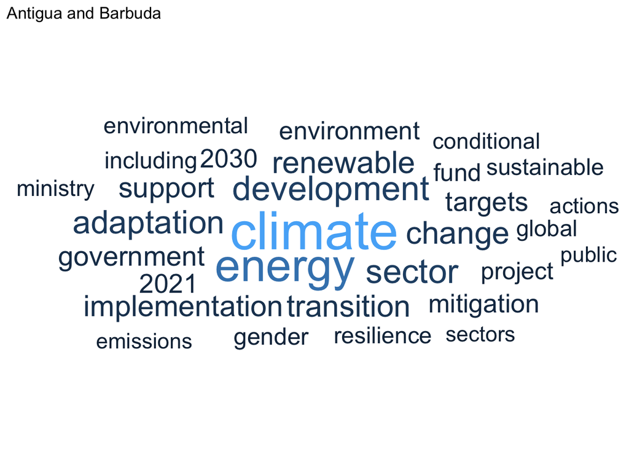

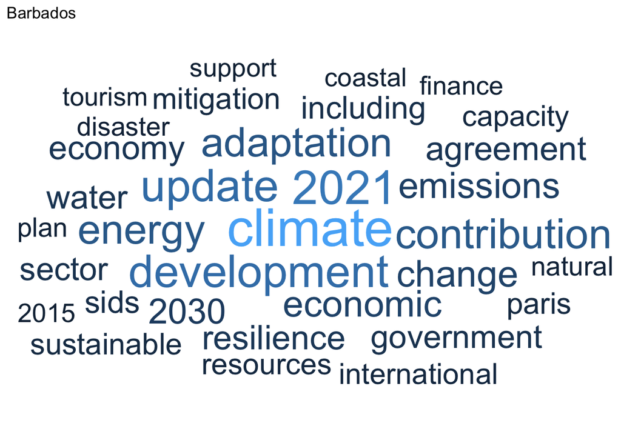

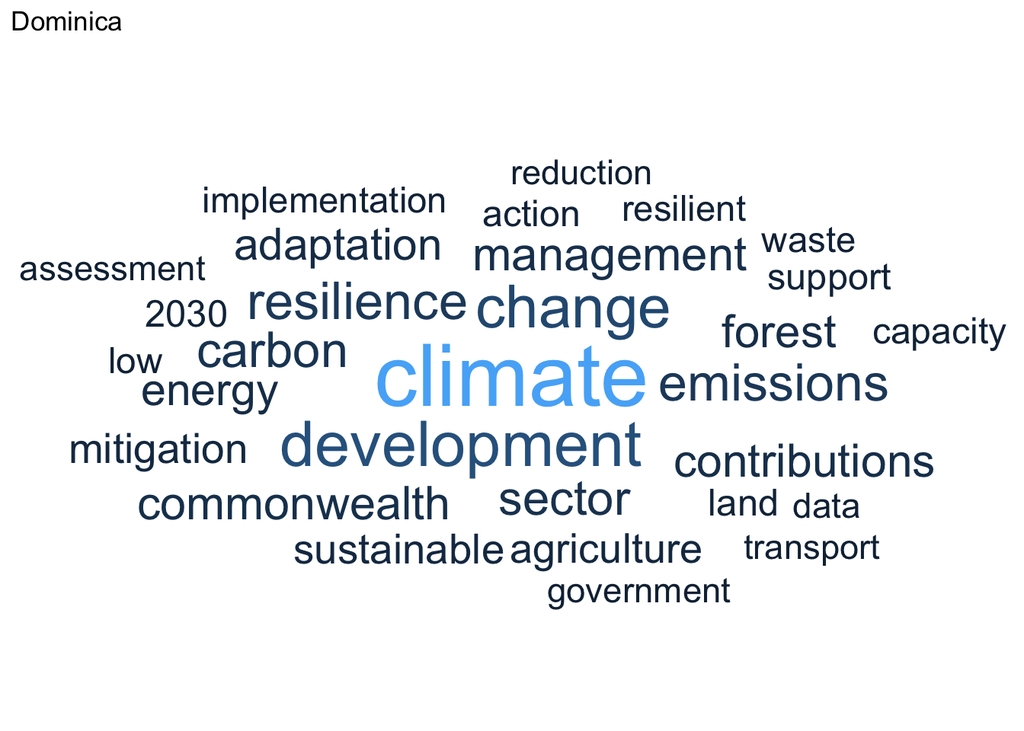

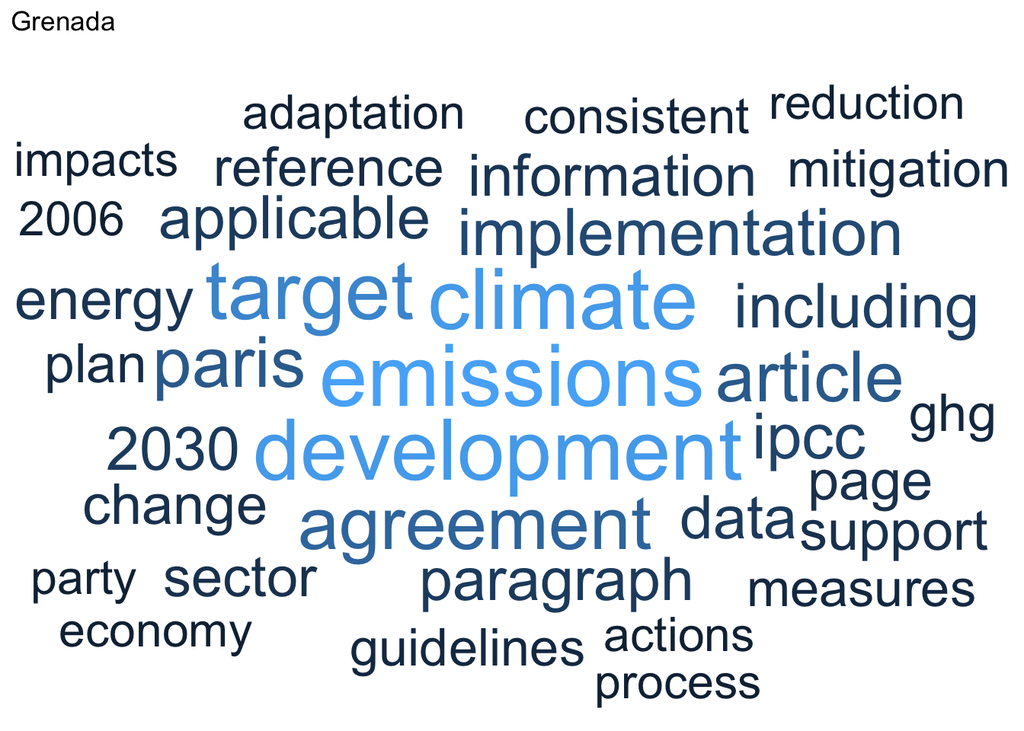

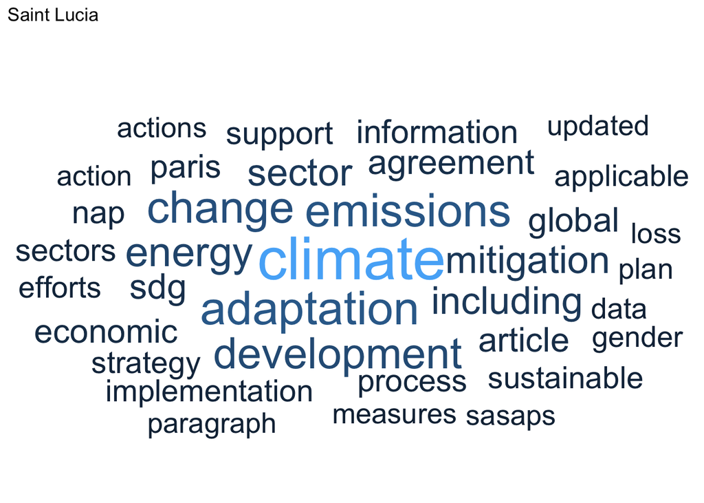

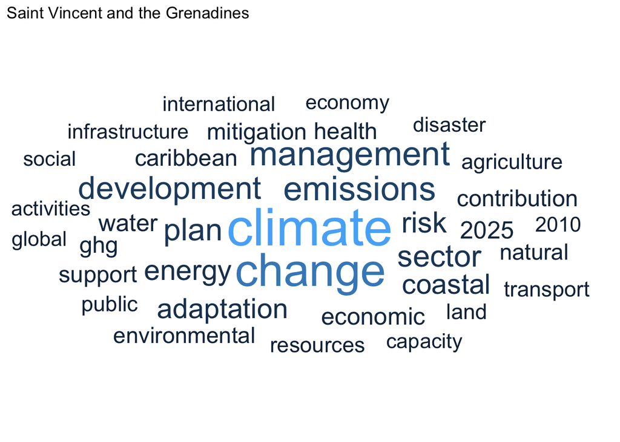

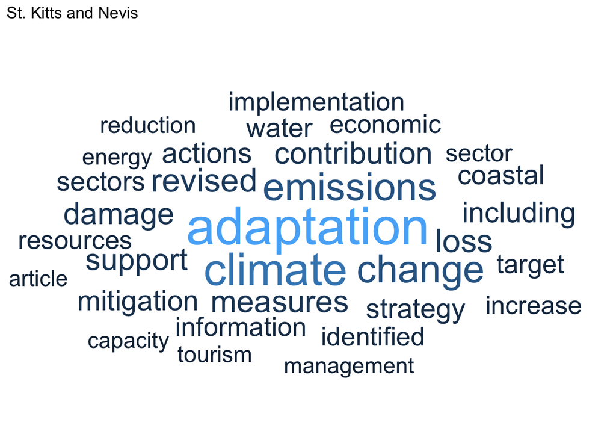

```r
library(ggwordcloud)
library(ggplot2)

# We'll store each plot in a list
plot_list <- list()

for (i in seq_len(nrow(dict_country))) {
  # Summarize data
  word_data <- df_tidy_wc |>
    filter(country == dict_country$country_abbr[i]) |>
    count(word, name = "freq") |>               # rename 'n' -> 'freq'
    slice_max(freq, n = 30)

  # Build the ggwordcloud
  p <- ggplot(word_data, aes(label = word, size = freq, color = freq)) +
    geom_text_wordcloud() +
    scale_size_area(max_size = 15) +
    theme_minimal() +
    ggtitle(dict_country$country_name[i])       # optional title

  # Store in our list
  plot_list[[i]] <- p
}

# Print all plots, one below the other
for (i in seq_along(plot_list)) {
  print(plot_list[[i]])
}
```

Focus on specific words and create a table with the frequency of these words for each country.

```r
search_elements <- c(
    "energy sector",
    "energy",
    "lulucf sector",
    "lulucf",
    "land use",
    "forestry",
    "forest",
    "forests",
    "wetlands",
    "watershed",
    "agriculture sector",
    "agriculture",
    "gender",
    "adaptation",
    "waste sector",
    "waste",
    "ippu",
    "industrial processes",
    "industrial processes and product use",
    "product use",
    "just transition",
    "transition",
    "urban",
    "health",
    "loss and damage",
    "children",
    "young people",
    "young",
    "youth",
    "circular economy",
    "circular",
    "green economy",
    "blue economy",
    "finance",
    "climate action",
    "voluntary cooperation",
    "voluntary",
    "mitigation",
    "transparency",
    "oceans",
    "biodiversity",
    "climate change")

df_search2 <- data.frame()

for (i in 1:length(search_elements)) {

df_search <-
    df_tidy2 |>
    filter(word == search_elements[i]) |>
    group_by(country_name) |>
    count() |>
    mutate(search_element = search_elements[i])

df_search2 <- df_search2 |> bind_rows(df_search)

}

df_search2 |> pivot_wider(names_from = search_element, values_from = n) |> reactable()
```

| country_name | energy sector | energy | lulucf sector | lulucf | land use | forestry | forest | forests | wetlands | watershed | agriculture sector | agriculture | gender | adaptation | waste sector | waste | ippu | industrial processes | product use | just transition | transition | urban | health | loss and damage | children | young people | youth | circular economy | circular | … |
| --- | --- | --- | --- | --- | --- | --- | --- | --- | --- | --- | --- | --- | --- | --- | --- | --- | --- | --- | --- | --- | --- | --- | --- | --- | --- | --- | --- | --- | --- | --- |
| Antigua and Barbuda | 12 | 174 | NA | NA | 6 | 9 | 1 | 1 | 1 | 5 | 1 | 22 | 48 | 88 | 3 | 18 | NA | NA | NA | 28 | 78 | 3 | 17 | 12 | 6 | NA | 33 | 4 | 4 | … |
| Barbados | 4 | 69 | NA | 1 | 6 | 1 | 1 | 1 | NA | NA | 1 | 8 | 6 | 67 | NA | 10 | 3 | 1 | 1 | NA | 3 | 5 | 8 | 9 | 1 | 1 | 3 | 1 | 1 | … |
| Dominica | 8 | 112 | 12 | 23 | 30 | 27 | 115 | 19 | 2 | 4 | 10 | 94 | 57 | 110 | 2 | 72 | NA | 5 | 4 | 9 | 30 | 3 | 44 | 6 | 1 | NA | 9 | 3 | 3 | … |
| Saint Lucia | 7 | 39 | NA | NA | NA | 1 | 11 | 2 | NA | NA | NA | 14 | 19 | 49 | NA | 1 | 1 | NA | NA | NA | 3 | 1 | 6 | 14 | 7 | NA | 8 | NA | NA | … |
| Saint Vincent and the Grenadines | 1 | 21 | 2 | 3 | 8 | 7 | 5 | 1 | NA | 2 | 2 | 12 | 1 | 20 | NA | 5 | NA | 2 | 2 | NA | NA | NA | 14 | NA | NA | NA | NA | NA | NA | … |
| St. Kitts and Nevis | 6 | 20 | NA | NA | 2 | 4 | 3 | 2 | NA | 1 | NA | 16 | 14 | 104 | NA | 5 | 5 | 2 | 1 | NA | 2 | 3 | 17 | 33 | 2 | NA | 2 | NA | 1 | … |
| Grenada | NA | 15 | NA | NA | 5 | 7 | 4 | 3 | NA | NA | NA | 9 | 5 | 10 | 1 | 7 | 5 | 1 | 1 | NA | 3 | 1 | 5 | 1 | 1 | NA | 3 | NA | NA | … |

```r
df_tidy2 |> filter(str_detect(word, "voluntary"))
```

```
    country                            word ngram        country_name
1   antigua                       voluntary     1 Antigua and Barbuda
2  barbados                       voluntary     1            Barbados
3  barbados                       voluntary     1            Barbados
4  dominica                       voluntary     1            Dominica
5  dominica                       voluntary     1            Dominica
6   grenada                       voluntary     1             Grenada
7     lucia                       voluntary     1         Saint Lucia
8     lucia                       voluntary     1         Saint Lucia
9     kitts                       voluntary     1 St. Kitts and Nevis
10  antigua                   use voluntary     2 Antigua and Barbuda
11  antigua           voluntary cooperation     2 Antigua and Barbuda
12 barbados                   the voluntary     2            Barbados
13 barbados              voluntary guidance     2            Barbados
14 barbados                   use voluntary     2            Barbados
```

[output cut: 38 more lines]

```r
df_tidy2 |>
    filter(str_detect(word, "mitigation")) |>
    filter(ngram > 1) |>
    reactable()
```

| country | word | ngram | country_name |
| --- | --- | --- | --- |
| antigua | 7.5 mitigation | 2 | Antigua and Barbuda |
| antigua | mitigation 31 | 2 | Antigua and Barbuda |
| antigua | for mitigation | 2 | Antigua and Barbuda |
| antigua | mitigation and | 2 | Antigua and Barbuda |
| antigua | in mitigation | 2 | Antigua and Barbuda |
| antigua | mitigation ambition | 2 | Antigua and Barbuda |
| antigua | c mitigation | 2 | Antigua and Barbuda |
| antigua | mitigation goal | 2 | Antigua and Barbuda |
| antigua | of mitigation | 2 | Antigua and Barbuda |
| antigua | mitigation and | 2 | Antigua and Barbuda |

[output cut: 1362 more lines]

```r
df_sentence |>
    filter(str_detect(sentence, "adaptation")) |>
    reactable()
```

| country | sentence |
| --- | --- |
| antigua | adaptation 27 7.3.1. |
| antigua | information necessary to facilitate clarity, transparency and understanding 37 references cited 63 list of acronyms ace action for climate empowerment af adaptation fund afolu agriculture, forestry an… |
| antigua | we will work to stimulate growth in green businesses that implement renewable energy and adaptation interventions. |
| antigua | this ndc will cover the period 2020 to 2030 and it includes targets for mitigation and adaptation as well as targets that are designed to: e reduce transitional risks, e support vulnerable groups, inc… |
| antigua | the ndc targets represent a significant increase in scope and ambition compared to the indc, specifically, in mitigation ambition and adaptation, with supporting actions in the 1 the government of ant… |
| antigua | summary of the ndc the ndc targets included in this submission are based on the 1.5°c mitigation goal and adaptation goals that assume a 3.4°c increase in global temperatures (based on projections fro… |
| antigua | if successful, this approach should reduce the overall cost of mitigation and adaptation projects, while reducing the importation of fossil fuel and concentrating on the abundant solar and wind energy… |
| antigua | gender addressing the gender dimension of climate change is a priority in antigua and barbuda due to the gender differentiated impacts and vulnerabilities experienced by women and men associated to cl… |
| antigua | the country is committed to achieving sdg 5: gender equality by promoting low carbon development where men and women contributions to climate change mitigation and adaptation are recognized and valued… |
| antigua | this is in line with the gender responsive targets for mitigation, adaptation and just transition sections: - 100% of female-headed households have all barriers removed to access back-up renewable ene… |

[output cut: 316 more lines]

```r
df_sentence |>
  filter(country == "lucia") |>
  filter(str_detect(sentence, "voluntary")) |>
  reactable()
```

| country | sentence |
| --- | --- |
| lucia | 7 during saint lucia’s 2019 voluntary national review (vnr) on the implementation of the 2030 agenda for sustainable development under the united nations high level political forum (hlpf), the progres… |
| lucia | the intention to use voluntary cooperation national level market-based instruments, such as cap-and- trade emission under article 6 of the paris agreement, if trading schemes and offsetting, are cruci… |

```r
reactable_list <- list()
country_list <- dict_country$country_abbr

for (i in 1:7) {

reactable_list[[i]] <-
  df_sentence |>
  filter(country == country_list[[i]]) |>
  filter(str_detect(sentence, "voluntary")) |>
  reactable()

}
```